# Melanoma Study: miRNAs and other variables predicting therapy response

Marc Bender

# Preamble

This document serves as a summary of the data analysis for the melanoma study using blood from patients to investigate several parameters, e.g. miRNA expression, staging, BRAF, etc. The basic question was to investigate differences in serum markers and its correlation to immunotherapy outcome. In a final step a predictive model should be developed to use certain markers to predict therapy outcome. All miRNAs in the following study were human miRNAs. Data is available at:

- Fireplex Analysis: https://raw.githubusercontent.com/MBender1992/MelanomaStudy/Marc/Data/miRNA_Expression_Fireplex_Melanoma_Study.csv
- Metadata: https://raw.githubusercontent.com/MBender1992/MelanomaStudy/Marc/Data/Metadata_Melanoma_Study.csv

### Loading of required packages

```r
# load packages "add publications of the respective packages"

# data wrangling
library(tidyverse)
library(data.table)
library(DescTools)
library(pbapply)
library(missForest)
# data visualization
library(ggpubr)
# statistical analysis
library(rstatix)
# summary table
library(table1)
# modelling/machine learning
library(caret)
library(pROC)
library(cvAUC)
# necessary to load data from github with "source_url"
library(devtools)

# load custom written functions
source_url("https://raw.githubusercontent.com/MBender1992/base_scripts/Marc/R_functions.R")
```

# 1. Patient characteristics

```r
load_melanoma_data <- function(){
  require(devtools)

  url_miR <- "https://raw.githubusercontent.com/MBender1992/MelanomaStudy/Marc/Data/miRNA_Expression_Fireplex_Melanoma_Study.csv"
  url_meta <- "https://raw.githubusercontent.com/MBender1992/MelanomaStudy/Marc/Data/Metadata_Melanoma_Study.csv"


  # load csv files
  dat_miR   <- read_csv(url(url_miR))
  dat_meta  <- read_csv(url(url_meta)) %>%
    select(-c(therapy_start, Abnahmedatum)) %>%
    mutate(TRIM_PDL1_Expression = str_replace_all(TRIM_PDL1_Expression,"\\++","+")) %>%
    mutate(TRIM_PDL1_Expression = ifelse(TRIM_PDL1_Expression == "o", NA,TRIM_PDL1_Expression)) %>%
    mutate(Stadium = toupper(Stadium)) %>%
    mutate(Stadium = str_extract(Stadium, "^[IV]{1,3}")) %>%
    mutate(BRAF = str_replace_all(BRAF, "\\.", "")) %>%
    mutate(breslow_thickness_mm = parse_number(breslow_thickness_mm))

    # change ID column to uniform capital letters for later filtering
  names(dat_miR) <- c("miRNA", toupper(names(dat_miR)[-1]))

  # define IDs to be dropped for further analyses
  controls <- c("K104_1", "K104_2", "K104_3A", "K104_3B")
  duplicates <- c("22B","38B","39B","47B")

  # wide miR data (78 patients with miRNA data)
  dat_miR_trans <- transpose_dataframe(colnames = c("ID",dat_miR$miRNA), data = dat_miR) %>%
    filter(!ID %in% controls & !ID %in% duplicates) %>%   #drop duplicate patient data
    mutate(ID = parse_number(ID)) #convert ID to numeric

  # join both tables
  right_join(dat_miR_trans,dat_meta, by="ID") %>%
    filter(!ID %in% c(1,2)) %>% # no data available for patient 1 and 2 but still part of the source table
    mutate(miRExpAssess = ifelse(is.na(rowSums(.[,which(str_detect(names(.),"mir"))])), 0,1))  %>%# if no miRNA expression has been measured fill in 0
    arrange(ID) %>%
    mutate(prior_BRAF_therapy = ifelse(str_detect(Vorbehandlung,"Mek|Dabra|Tafinlar|Tefinlar|MEK|BRAF|Vemu|[zZ]ellboraf"), 1, 0)) %>%
    select(-Vorbehandlung)
}

dat <- load_melanoma_data() %>%
  mutate(Responder =  factor(Responder, levels = c("nein", "ja") , labels = c("no", "yes")))
dat
```

| ID | hsa-mir-9-5p | hsa-mir-15a-5p | hsa-mir-15b-5p | hsa-mir-16-5p | hsa-mir-20a-5p | hsa-mir-20b-5p | hsa-mir-21-5p | hsa-mir-23a-3p | hsa-mir-23b-3p | hsa-mir-29a-3p | hsa-mir-29c-3p | hsa-mir-30d-5p | hsa-mir-31-3p | hsa-mir-31-5p | hsa-mir-33a-5p | hsa-mir-34a-3p | hsa-mir-34a-5p | hsa-mir-93-5p | hsa-mir-101-3p | hsa-mir-124-3p | hsa-mir-132-3p | hsa-mir-137 | hsa-mir-142-3p | hsa-mir-142-5p | hsa-mir-145-5p | hsa-mir-146b-5p | hsa-mir-148a-3p | hsa-mir-150-5p | hsa-mir-155-5p | … |
| --- | --- | --- | --- | --- | --- | --- | --- | --- | --- | --- | --- | --- | --- | --- | --- | --- | --- | --- | --- | --- | --- | --- | --- | --- | --- | --- | --- | --- | --- | --- |
| 3 | NA | NA | NA | NA | NA | NA | NA | NA | NA | NA | NA | NA | NA | NA | NA | NA | NA | NA | NA | NA | NA | NA | NA | NA | NA | NA | NA | NA | NA | … |
| 4 | NA | NA | NA | NA | NA | NA | NA | NA | NA | NA | NA | NA | NA | NA | NA | NA | NA | NA | NA | NA | NA | NA | NA | NA | NA | NA | NA | NA | NA | … |
| 5 | NA | NA | NA | NA | NA | NA | NA | NA | NA | NA | NA | NA | NA | NA | NA | NA | NA | NA | NA | NA | NA | NA | NA | NA | NA | NA | NA | NA | NA | … |
| 6 | NA | NA | NA | NA | NA | NA | NA | NA | NA | NA | NA | NA | NA | NA | NA | NA | NA | NA | NA | NA | NA | NA | NA | NA | NA | NA | NA | NA | NA | … |
| 7 | NA | NA | NA | NA | NA | NA | NA | NA | NA | NA | NA | NA | NA | NA | NA | NA | NA | NA | NA | NA | NA | NA | NA | NA | NA | NA | NA | NA | NA | … |
| 8 | NA | NA | NA | NA | NA | NA | NA | NA | NA | NA | NA | NA | NA | NA | NA | NA | NA | NA | NA | NA | NA | NA | NA | NA | NA | NA | NA | NA | NA | … |
| 9 | NA | NA | NA | NA | NA | NA | NA | NA | NA | NA | NA | NA | NA | NA | NA | NA | NA | NA | NA | NA | NA | NA | NA | NA | NA | NA | NA | NA | NA | … |
| 10 | 1.8 | 2944.6 | 1681.3 | 13051.8 | 5180.7 | 3265.4 | 7016.2 | 5506.0 | 4063.0 | 4210.3 | 3152.0 | 855.0 | 2.2 | 7.6 | 138.2 | 3.0 | 290.4 | 4883.3 | 2.3 | 5.3 | 109.1 | 2.6 | 622.2 | 644.4 | 581.1 | 1091.5 | 2138.3 | 1138.7 | 57.5 | … |
| 11 | NA | NA | NA | NA | NA | NA | NA | NA | NA | NA | NA | NA | NA | NA | NA | NA | NA | NA | NA | NA | NA | NA | NA | NA | NA | NA | NA | NA | NA | … |
| 12 | 2.5 | 2836.8 | 1346.7 | 9214.3 | 3782.7 | 3023.0 | 3977.9 | 5731.8 | 4099.9 | 3604.8 | 2603.1 | 390.3 | 1.0 | 0.8 | 68.3 | 2.0 | 166.5 | 5504.1 | 7.1 | 0.5 | 61.9 | 0.7 | 453.6 | 744.8 | 522.7 | 1031.4 | 1333.0 | 745.5 | 12.1 | … |

[output cut: 91 more lines]

To gain insights of the different patients a summary table was generated showing several different features split by immunotherapy response (Table 1).

```r
dat_table1 <- dat
setDT(dat_table1)

# define which factors to display in table
dat_table1$sex <- factor(dat_table1$sex, levels = c("m", "w") , labels = c("Male", "Female"))
dat_table1$miRExpAssess <- factor(dat_table1$miRExpAssess, levels = c(0, 1) , labels = c("no", "yes"))
dat_table1$Responder <- factor(dat_table1$Responder, levels = c("no", "yes",2) , labels = c("no", "yes","P-value"))
dat_table1$adjuvant_IFN <- factor(dat_table1$adjuvant_IFN, levels = c("nein", "ja") , labels = c("no", "yes"))
dat_table1$brainMet <- factor(dat_table1$brainMet, levels = c("nein", "ja") , labels = c("no", "yes"))
dat_table1$subtype <- factor(dat_table1$subtype, levels = c("cutanes Melanom", "Schleimhautmelanom") , labels = c("cutaneous", "mucosal"))
dat_table1$ECOG <- factor(dat_table1$ECOG, levels = c(0,1,2) , labels = c("0", "1", "2"))
dat_table1$Stadium <- factor(dat_table1$Stadium, levels = c("II", "III","IV") , labels = c("II", "III","IV"))
dat_table1$prior_BRAF_therapy <- factor(dat_table1$prior_BRAF_therapy, levels = c(0, 1) , labels = c("no", "yes"))


# define labels for the table
label(dat_table1$Alter)      <- "Age (years)"
label(dat_table1$BRAF)      <- "BRAF-status"
label(dat_table1$Stadium)  <- "AJCC stage" # add Stadium to source table
label(dat_table1$therapy_at_blood_draw) <- "Therapy at blood draw"
label(dat_table1$sex)  <- "Sex"
label(dat_table1$Responder)  <- "Immunotherapy response"
label(dat_table1$ECOG)      <- "ECOG"
label(dat_table1$breslow_thickness_mm)      <- "Breslow thickness (mm)" # change to double
label(dat_table1$subtype) <- "Subtype"
label(dat_table1$localization) <- "Localization"
label(dat_table1$brainMet) <- "Brain metastasis"
label(dat_table1$miRExpAssess) <- "miRNA expression measured"
label(dat_table1$adjuvant_IFN) <- "Received adjuvant IFN treatment"
label(dat_table1$prior_BRAF_therapy) <- "Received prior anti-BRAF therapy"


# function to display p-values
rndr <- function(x, name, ...) {
  if (length(x) == 0) {
    y <- dat_table1[[name]]
    ind <- !is.na(y)
    y <- y[ind]
    s <- rep("", length(render.default(x=y, name=name, ...)))
    if (is.numeric(y)) {
      p <- t.test(y ~ dat_table1$Responder[ind])$p.value
    } else {
      p <- chisq.test(table(y, droplevels(dat_table1$Responder[ind])))$p.value
    }
    s[2] <- sub("<", "&lt;", format.pval(p, digits=3, eps=0.001))
    s
  } else {
    render.default(x=x, name=name, ...)
  }
}

rndr.strat <- function(label, n, ...) {
  ifelse(n==0, label, render.strat.default(label, n, ...))
}

# define text for footnote
fn <- "Statistical test: Unequal variance t-test (welch's t-test) for numerical data and chi² test for categorical data. Raw p-values are shown."

table1(~ Alter + BRAF + prior_BRAF_therapy + Stadium + miRExpAssess + adjuvant_IFN + brainMet + sex + ECOG + breslow_thickness_mm + subtype + localization | Responder,
       data=dat_table1, droplevels=F, render=rndr, render.strat=rndr.strat, footnote = fn)
```

```
Chi-squared approximation may be incorrectChi-squared approximation may be incorrectChi-squared approximation may be incorrectChi-squared approximation may be incorrect
```

|  | no (N=45) | yes (N=36) | P-value | Overall (N=101) |
| --- | --- | --- | --- | --- |
| Age (years) |  |  |  |  |
| Mean (SD) | 59.4 (17.1) | 68.0 (14.3) | 0.0319 | 63.4 (15.3) |
| Median [Min, Max] | 57.5 [31.0, 87.0] | 73.0 [36.0, 92.0] |  | 67.0 [31.0, 92.0] |
| Missing | 11 (24.4%) | 5 (13.9%) |  | 17 (16.8%) |
| BRAF-status |  |  |  |  |
| neg | 17 (37.8%) | 23 (63.9%) | 0.0536 | 45 (44.6%) |
| pos | 26 (57.8%) | 13 (36.1%) |  | 50 (49.5%) |
| Missing | 2 (4.4%) | 0 (0%) |  | 6 (5.9%) |
| Received prior anti-BRAF therapy |  |  |  |  |
| no | 15 (33.3%) | 25 (69.4%) | 0.0081 | 52 (51.5%) |
| yes | 18 (40.0%) | 6 (16.7%) |  | 29 (28.7%) |
| Missing | 12 (26.7%) | 5 (13.9%) |  | 20 (19.8%) |
| AJCC stage |  |  |  |  |
| II | 0 (0%) | 1 (2.8%) | 0.498 | 2 (2.0%) |
| III | 6 (13.3%) | 4 (11.1%) |  | 20 (19.8%) |
| IV | 39 (86.7%) | 28 (77.8%) |  | 76 (75.2%) |
| Missing | 0 (0%) | 3 (8.3%) |  | 3 (3.0%) |
| miRNA expression measured |  |  |  |  |
| no | 11 (24.4%) | 9 (25.0%) | 1 | 23 (22.8%) |
| yes | 34 (75.6%) | 27 (75.0%) |  | 78 (77.2%) |
| Received adjuvant IFN treatment |  |  |  |  |
| no | 19 (42.2%) | 19 (52.8%) | 1 | 46 (45.5%) |
| yes | 10 (22.2%) | 10 (27.8%) |  | 28 (27.7%) |
| Missing | 16 (35.6%) | 7 (19.4%) |  | 27 (26.7%) |
| Brain metastasis |  |  |  |  |
| no | 16 (35.6%) | 18 (50.0%) | 0.62 | 48 (47.5%) |
| yes | 10 (22.2%) | 7 (19.4%) |  | 18 (17.8%) |
| Missing | 19 (42.2%) | 11 (30.6%) |  | 35 (34.7%) |
| Sex |  |  |  |  |
| Male | 25 (55.6%) | 23 (63.9%) | 0.595 | 58 (57.4%) |
| Female | 20 (44.4%) | 13 (36.1%) |  | 43 (42.6%) |
| ECOG |  |  |  |  |
| 0 | 19 (42.2%) | 23 (63.9%) | 0.094 | 58 (57.4%) |
| 1 | 18 (40.0%) | 11 (30.6%) |  | 32 (31.7%) |
| 2 | 8 (17.8%) | 2 (5.6%) |  | 11 (10.9%) |
| Breslow thickness (mm) |  |  |  |  |
| Mean (SD) | 6.21 (8.13) | 4.05 (2.54) | 0.139 | 4.96 (6.10) |
| Median [Min, Max] | 2.95 [0.600, 38.0] | 3.20 [1.00, 9.20] |  | 3.00 [0.600, 38.0] |
| Missing | 9 (20.0%) | 7 (19.4%) |  | 18 (17.8%) |
| Subtype |  |  |  |  |
| cutaneous | 40 (88.9%) | 31 (86.1%) | 0.807 | 90 (89.1%) |
| mucosal | 2 (4.4%) | 3 (8.3%) |  | 5 (5.0%) |
| Missing | 3 (6.7%) | 2 (5.6%) |  | 6 (5.9%) |
| Localization |  |  |  |  |
| acral | 4 (8.9%) | 5 (13.9%) | 0.826 | 11 (10.9%) |
| anal | 2 (4.4%) | 1 (2.8%) |  | 3 (3.0%) |
| extremities | 10 (22.2%) | 8 (22.2%) |  | 24 (23.8%) |
| head / neck | 8 (17.8%) | 6 (16.7%) |  | 17 (16.8%) |
| trunk | 17 (37.8%) | 11 (30.6%) |  | 36 (35.6%) |
| vulva | 0 (0%) | 1 (2.8%) |  | 1 (1.0%) |
| Missing | 4 (8.9%) | 4 (11.1%) |  | 9 (8.9%) |

Statistical test: Unequal variance t-test (welch's t-test) for numerical data and chi² test for categorical data. Raw p-values are shown.

# 2. Association of different parameters with therapy response

## 2.1 Serum markers

```r
dat_serum_markers_tidy <- dat %>%
  select(c(ID, Responder,Baseline, Eosinophile, CRP, LDH, S100)) %>%
  gather(serum_marker, value,-c(ID, Responder,Baseline)) %>%
  mutate(log_val = ifelse(is.infinite(log2(value)), 0, log2(value))) %>%
  filter(!is.na(log_val))

# plot 4 markers in separate plots and calculate statistics
plot_serum_markers <- signif_plot_Melanoma(dat_serum_markers_tidy, x="Responder", y="log_val", p.adj = "fdr",
                     plot.type = "dotplot", significance=FALSE, Legend = FALSE, ylab = "log2 serum marker concentration",
                     method ="t.test", p.label="{p.signif}", facet="serum_marker")
```

```
Results filtered by raw p-values
```

```r
# show results of statistical analysis
plot_serum_markers$stat_test_results
```

| serum_marker | .y. | group1 | group2 | p | p.adj | p.format | p.signif | method | p.adj.signif |
| --- | --- | --- | --- | --- | --- | --- | --- | --- | --- |
| Eosinophile | log_val | no | yes | 0.0129652523 | 0.01300 | 0.0130 | * | T-test | * |
| CRP | log_val | no | yes | 0.0020217853 | 0.00290 | 0.0020 | ** | T-test | ** |
| LDH | log_val | no | yes | 0.0001982926 | 0.00079 | 0.0002 | *** | T-test | *** |
| S100 | log_val | no | yes | 0.0021975097 | 0.00290 | 0.0022 | ** | T-test | ** |

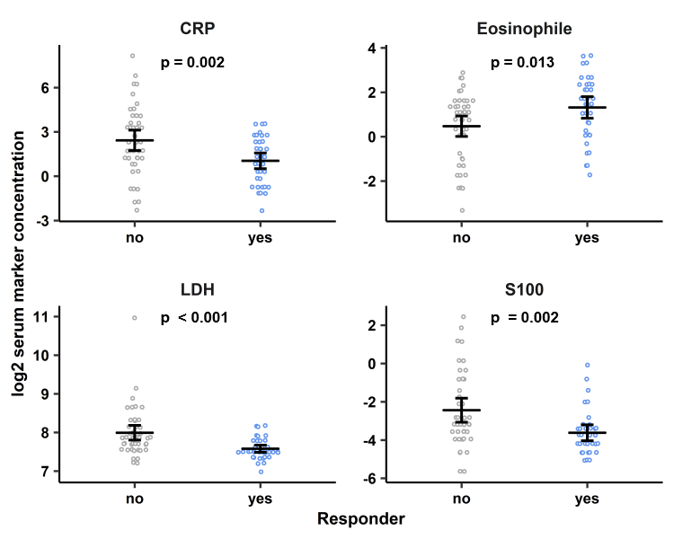

## 2.2 miRNAs

```r
# tidy miRNA data.....................................................................................................
dat_miRNA_tidy <- dat %>%
  # only use data where miRNA data was measured and responder status is known
  filter(miRExpAssess == 1 & !is.na(Responder)) %>%
  gather(miRNA, expression, contains("hsa")) %>%
  mutate(miRNA = str_replace_all(.$miRNA, "hsa-","")) %>%
  mutate(log_exp = log2(expression),
         Responder =  factor(Responder, levels = c("nein", "ja") , labels = c("no", "yes")))

# Plot miRNA data
plot_miRNA <- signif_plot_Melanoma(dat_miRNA_tidy, x="Responder", y="log_exp", signif=0.05, p.adj = "fdr",
                     plot.type = "dotplot", significance=F, Legend = F, var.equal = F,
                     method ="t.test", p.label="p = {round(p,4)}",p.size = 3, facet="miRNA")
```

```
Results filtered by raw p-values
```

```r
# show results of statistical analysis
plot_miRNA$stat_test_results
```

| miRNA | .y. | group1 | group2 | p | p.adj | p.format | p.signif | method | p.adj.signif |
| --- | --- | --- | --- | --- | --- | --- | --- | --- | --- |
| mir-132-3p | log_exp | no | yes | 0.02526087 | 0.47 | 0.025 | * | T-test | ns |
| mir-137 | log_exp | no | yes | 0.02178516 | 0.47 | 0.022 | * | T-test | ns |
| mir-197-3p | log_exp | no | yes | 0.03324073 | 0.47 | 0.033 | * | T-test | ns |
| mir-214-3p | log_exp | no | yes | 0.03783529 | 0.47 | 0.038 | * | T-test | ns |
| mir-514a-3p | log_exp | no | yes | 0.04805282 | 0.47 | 0.048 | * | T-test | ns |

[figure not shown]

**Fig. 2: log2 miRNA expression (a.u.).** Crossbars show mean ± sd. Unequal variances t-test. Raw p-values.

# 3 Modelling process

The initial data was filtered to only keep rows with data for immunotherapy response and miRNA expression resulting in n = 61 for the modelling process. Each categorical variable was checked for enough elements in each group when split by immunotherapy response to remove features with high uncertainty (a model using e.g. ECOG containing 2 patients with immunotherapy response and ECOG 2 and 4 patients without immunotherapy and ECOG 2 will be rather uninformative as this variable adds noise instead of useful information). On top of that breslow thickness and BRAF status were dropped from the analysis as the former is highly correlated with the AJCC stage and included in that variable and the latter is highly correlated with prior anti-BRAF treatment (which is a more useful variable as it is known, that patients with a prior BRAF therapy have worse immunotherapy response).

```r
#####################################
##
## 1.Data preprocessing
##
#####################################

# filter data to keep only rows with data for immunotherapy response and miRNA expression and transform categorical variables to factors
dat_fct <- dat %>%
  filter(miRExpAssess == 1 & !is.na(Responder)) %>% # n = 61
  select(-c(TRIM_PDL1_Expression , miRExpAssess, therapy_at_blood_draw)) %>%
  mutate( across(c(Responder, Stadium, Baseline, BRAF, ECOG, subtype, localization,
                   sex, brainMet, adjuvant_IFN, organsInvolved, nras, prior_BRAF_therapy), as.factor))

# check each factor for enough elements when split by responder
xtabs(~ Responder + Stadium, data=dat_fct)
```

```
         Stadium
Responder II III IV
      no   0   5 29
      yes  1   3 22
```

```r
xtabs(~ Responder + BRAF, data=dat_fct)
```

```
         BRAF
Responder neg pos
      no   10  22
      yes  18   9
```

```r
xtabs(~ Responder + Baseline, data=dat_fct)
```

```
         Baseline
Responder ja nein
      no  15   16
      yes  8   19
```

```r
xtabs(~ Responder + ECOG, data=dat_fct) # not enough samples in ECOG2
```

```
         ECOG
Responder  0  1  2
      no  16 14  4
      yes 15 10  2
```

```r
xtabs(~ Responder + subtype, data=dat_fct) # too many groups with few samples
```

```
         subtype
Responder cutanes Melanom Schleimhautmelanom
      no               31                  1
      yes              23                  3
```

```r
xtabs(~ Responder + localization, data=dat_fct) # too many groups with few samples
```

```
         localization
Responder acral anal extremities head / neck trunk vulva
      no      3    1           8           7    12     0
      yes     4    1           7           4     8     1
```

```r
xtabs(~ Responder + sex, data=dat_fct)
```

```
         sex
Responder  m  w
      no  18 16
      yes 16 11
```

```r
xtabs(~ Responder + brainMet, data=dat_fct)
```

```
         brainMet
Responder ja nein
      no  10   16
      yes  7   18
```

```r
xtabs(~ Responder + adjuvant_IFN, data=dat_fct)
```

```
         adjuvant_IFN
Responder ja nein
      no   9   15
      yes  8   15
```

```r
xtabs(~ Responder + organsInvolved, data=dat_fct) # too few observations
```

```
         organsInvolved
Responder  0  1  2  3  4
      no   0  8  6 10  3
      yes  1  4 12  7  1
```

```r
xtabs(~ Responder + nras, data=dat_fct) # too few observations
```

```
         nras
Responder pos
      no    2
      yes   1
```

```r
xtabs(~ Responder + prior_BRAF_therapy, data=dat_fct)
```

```
         prior_BRAF_therapy
Responder  0  1
      no  11 16
      yes 19  5
```

```r
# remove columns that yield high uncertainty
dat_fct$ECOG <- NULL
dat_fct$subtype <- NULL
dat_fct$localization <- NULL
dat_fct$nras <- NULL
dat_fct$Baseline <- NULL
dat_fct$ID <- NULL
dat_fct$organsInvolved <- NULL
dat_fct$breslow_thickness_mm <- NULL # included in stage variable
dat_fct$BRAF <- NULL # highly correlated with prior BRAF therapy and therefore rather adds noise to the model
```

The dataset contained several variables with missing values. To balance uncertainty introduced by replacing missing values and keeping important variables variables with less than 20 % missing values were kept in the analysis and missing values were imputed using a random forest algorithm from the missForest package in R.

```r
#####################################
##
## 1.a Impute missing values
##
#####################################

# detect percentage of NAs in each column
NAs <- sapply(dat_fct, function(df){
  sum(is.na(df) ==TRUE)/length(df);
})

# remove columns with more than 20 % NAs
dat_fct <- dat_fct[, -which(NAs > 0.2)]

# convert factor columns to numerical
dat_fct$Stadium <- ifelse(dat_fct$Stadium == "II", 2,ifelse(dat_fct$Stadium == "III", 3, 4))
dat_fct$sex <- ifelse(dat_fct$sex == "m", 1, 0)
dat_fct$brainMet <- ifelse(dat_fct$brainMet == "ja", 1, 0)
dat_fct$prior_BRAF_therapy <- parse_number(as.character(dat_fct$prior_BRAF_therapy))

# impute missing values with random forest algorithm
set.seed(25)
dat_imp <- dat_fct %>%
  select_if(is.numeric) %>%
  as.data.frame() %>%
  missForest() %>%
  .$ximp %>%
  # replace calculated probabilities by the factor
  mutate(Stadium = round(Stadium),
         Alter = round(Alter),
         brainMet = ifelse(brainMet > 0.5, 1,0),
         prior_BRAF_therapy = ifelse(prior_BRAF_therapy > 0.5, 1, 0))

# replace numerical values by factor for encoding later
dat_imp$sex <- factor(dat_imp$sex, levels = c(0,1), labels = c("w", "m"))
dat_imp$brainMet <- factor(dat_imp$brainMet, levels = c(0,1), labels = c("no", "yes"))
dat_imp$prior_BRAF_therapy  <- factor(dat_imp$prior_BRAF_therapy, levels = c(0,1), labels = c("no", "yes"))

# replacing NAs with imputed values
dat_fct$Stadium <- dat_imp$Stadium
dat_fct$S100 <- dat_imp$S100
dat_fct$Alter<- dat_imp$Alter
dat_fct$brainMet <- dat_imp$brainMet
dat_fct$prior_BRAF_therapy <- dat_imp$prior_BRAF_therapy
dat_fct$sex <- dat_imp$sex
```

To inspect the data and underlying structure the data was split randomly into training and test set in a 70/30 ratio for explorative data analysis. (This split ensured that decisions based on EDA were less than biased than with using the whole dataset).

```r
#####################################
##
##  2. Modeling process
##
#####################################

# define test and training set
set.seed(123)
ind.train <- createDataPartition(dat_fct$Responder, p = 0.7, list = FALSE)

train.EDA  <- dat_fct[ind.train, ] # n = 43
test.EDA <- dat_fct[-ind.train, ] # n = 18

#####################################
##
##  2.a EDA on training set (to avoid drawing conclusions including the test set)
##
#####################################

# change data structure for ggplot
dat_miR <- train.EDA %>%
  select(contains("mir")) %>%
  gather("miRNA", "expression")

# draw histograms for all miRNAs
miR_hist <- dat_miR %>%
  ggplot(aes(expression)) +
  geom_histogram(color = "black", fill = "grey") +
  facet_wrap(~miRNA, scales = "free") +
  theme_bw()

# draw qqplots for all miRNAs
miR_qq <- dat_miR %>%
  ggplot(aes(sample = expression)) +
  geom_qq() +
  geom_qq_line() +
  facet_wrap(~miRNA, scales = "free")+
  theme_bw()
```

[figure not shown]

**Fig. 3: Histogram of miRNAs** .

[figure not shown]

**Fig. 4: qqplot of miRNAs** .

```r
# draw histograms for all miRNAs log-transformed
miR_hist_log <- dat_miR %>%
  ggplot(aes(log(expression))) +
  geom_histogram() +
  facet_wrap(~miRNA, scales = "free")

# draw qqplots for all miRNAs log-transformed
miR_qq_log <- dat_miR %>%
  ggplot(aes(sample = log(expression))) +
  geom_qq() +
  geom_qq_line() +
  facet_wrap(~miRNA, scales = "free")

## log-transforming miRNA expression improves approximation to normality and gene expression data is known to be log-normal distributed
## log-transformed miRNA values were used for ML

# histogram of numerical variables that are not miRNAs
par(mfrow = c(2,4))
par(mar=c(0.5, 4.5, 0.5, 0.5))

# original expression values
hist(train.data$LDH)
hist(train.data$Eosinophile)
hist(train.data$S100)
hist(train.data$CRP)

# log-transformed expression values
hist(log(train.data$LDH))
hist(log(train.data$Eosinophile))
hist(log(train.data$S100))
hist(log(train.data$CRP))
```

Guideline: https://www.ncbi.nlm.nih.gov/pmc/articles/PMC5217944/

Glm modeling mit glm und Koeffizienten oder glmnet?

Explanation of Ridge, Lasso and Elastic Net Regularization

relaxed Lasso: Meinshausen 2007

https://machinelearningmastery.com/nested-cross-validation-for-machine-learning-with-python/

Using nested cv as it closely resembles test on independent validation set (https://bmcbioinformatics.biomedcentral.com/articles/10.1186/1471-2105-7-91) and leads to less bias than traditional cv: https://www.ncbi.nlm.nih.gov/pmc/articles/PMC1397873/

discussion why we used this challenging dataset: Papr: A feature agnostic approach for glaucoma detection in OCT volumes